# MTH6139 Time Series

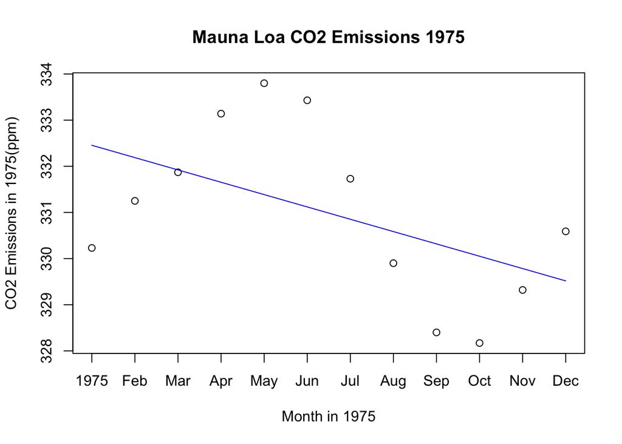

```r
co2_1975 <- subset(co2.df, format(ds, "%Y") == "1975")
model_1975 <-lm(y~ds, data = co2_1975)
plot(co2_1975$ds, co2_1975$y, main = "Mauna Loa CO2 Emissions 1975", ylab = "CO2 Emissions in 1975(ppm)", xlab = "Month in 1975")
lines(co2_1975$ds, predict(model_1975), col = "blue")
```

The emissions show the same cyclic pattern of CO2 emissions, with emissions in 1975 decreased slightly from where they were estimated to be using the slope of the linear regressions (1.308)performed above. Further, the cyclic pattern remains for both years, showing that emissions may have decreased slightly due to the Clean Air Act across the entire year instead of reducing emissions across specific months. This also shows the difficulty in legislation substaintially impacting CO2 emissions.

Lastly, I want to use Meta’s Prophet to forecast future data based on Mauna Loa’s CO2 Emissions recorded data. This will help understand future CO2 emissions, specifically important in setting CO2 emission reduction goals.

```r
m = prophet::prophet(co2.df)
```

```
## Disabling weekly seasonality. Run prophet with weekly.seasonality=TRUE to override this.
```

```
## Disabling daily seasonality. Run prophet with daily.seasonality=TRUE to override this.
```

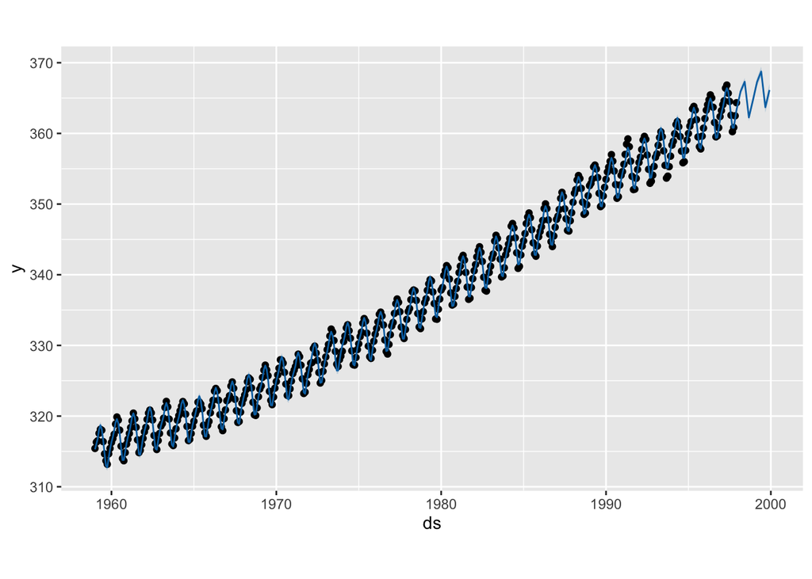

```r
f = prophet::make_future_dataframe(m, periods=8, freq="quarter")
p = predict(m, f)
plot(m,p)
```